# Practical Machine Learning

tndl

09 August 2020

## Introduction

One thing that people regularly do is quantify how much of a particular activity they do, but they rarely quantify how well they do it. In this project, your goal will be to use data from accelerometers on the belt, forearm, arm, and dumbell of 6 participants. * Culled from Coursera course on Practical Machine Learning

Link to GitHub: https://github.com/ThandoNdl/datasciencecoursera/blob/master/PML%20Report.Rmd

## Data Preparation

We have been provided with data that we split into training and testing.

```r
#Read in datasets
setwd("~/Coursera/Course 8")
pml_training = read.csv("pml-training.csv", na.strings = c("NA", " ", ""))
pml_testing = read.csv("pml-testing.csv", na.strings = c("NA", " ", ""))
target_var = "classe"
```

Our variable of interest is "classe".

### Dataframe Exploration

```
##
##    A    B    C    D    E
## 5580 3797 3422 3216 3607
```

```
##
##         A         B         C         D         E
## 0.2843747 0.1935073 0.1743961 0.1638977 0.1838243
```

### Data Preparation

#### Data Cleaning

##### Record Id columns

We are only interested in columns that can be considered predictors for our target variable so we removed the following columns: "user_name", "cvtd_timestamp", "X", "raw_timestamp_part_1", "raw_timestamp_part_2"

##### Missing value columns

There were quite a number of columns that were almost completely filled (>90%) with missing values so these were removed as well.

```r
# Remove columns with lots of missing values
training_DF = training_DF[, colSums(is.na(training_DF)) <=0.9*nrow(training_DF)]
```

##### One-Hot Encoding

Categorical variables will be changed to binary integer variables using one-hot encoding.

Since there is only one categorical variable, and it only has 2 factors, we will just transform one of the factors.

```r
table(training_DF$new_window)
```

```
##
##    no   yes
## 19216   406
```

```r
training_DF$new_windowno <- ifelse(training_DF$new_window=="no", 1, 0)
table(training_DF$new_windowno)
```

```
##
##     0     1
##   406 19216
```

```r
training_DF$new_window = NULL
```

### Model Preparation

##### Correlation

```r
library(ggplot2)
# Correlations
#str(training_DF)
r <- cor(training_DF[,!(names(training_DF) %in% target_var), drop = F], use="complete.obs")
#round(r,2)
ggcorrplot(r, hc.order = TRUE, type = "lower")
```

*** Output was excluded as it was too large

##### Traing, Validation, Test Sets

The training data will be split so we can get a validation set

```r
# Split training into training and validation
set.seed(2020)
training_DF_random = training_DF[sample(nrow(training_DF)),]
set.seed(2020)
trainIndex = createDataPartition(training_DF_random$classe, p = 0.7, list = FALSE)
training = training_DF_random[trainIndex,]; validation = training_DF_random[-trainIndex,]

train.data = training[,!(names(training) %in% target_var), drop = F]
valid.data = validation[,!(names(validation) %in% target_var), drop = F]

# Check if proportion of target align with overall set
prop.table(table(training[, target_var]))
```

```
##
##         A         B         C         D         E
## 0.2843416 0.1934920 0.1744195 0.1639368 0.1838101
```

```r
prop.table(table(validation[, target_var]))
```

```
##
##         A         B         C         D         E
## 0.2844520 0.1935429 0.1743415 0.1638063 0.1838573
```

### Model Training

We will be using the caret package to train, fit and test a few models.

We set the training parameters and the accuracy metric to consider for model comparison.

```r
control <- trainControl(method="repeatedcv", number=3, repeats=1)
seed <- 7
metric <- "Accuracy"
set.seed(seed)
```

#### Boosting

The first 2 model we will try are boosting alogorithms : c50 and GBM.

#### Results

```r
results <- resamples(list(treebag=fit.treebag, rf=fit.rf, c50=fit.c50, gbm=fit.gbm))
summary(results)
```

```
##
## Call:
## summary.resamples(object = results)
##
## Models: treebag, rf, c50, gbm
## Number of resamples: 3
##
## Accuracy
##              Min.   1st Qu.    Median      Mean   3rd Qu.      Max. NA's
## treebag 0.9873335 0.9895174 0.9917012 0.9903181 0.9918104 0.9919196    0
## rf      0.9945403 0.9948679 0.9951955 0.9953410 0.9957414 0.9962874    0
## c50     0.9967242 0.9971607 0.9975972 0.9978888 0.9984711 0.9993450    0
## gbm     0.9702992 0.9734684 0.9766376 0.9746670 0.9768509 0.9770642    0
##
## Kappa
##              Min.   1st Qu.    Median      Mean   3rd Qu.      Max. NA's
## treebag 0.9839781 0.9867403 0.9895025 0.9877534 0.9896410 0.9897795    0
## rf      0.9930934 0.9935081 0.9939229 0.9941069 0.9946136 0.9953044    0
## c50     0.9958565 0.9964087 0.9969608 0.9973296 0.9980662 0.9991715    0
## gbm     0.9624182 0.9664340 0.9704498 0.9679479 0.9707127 0.9709756    0
```

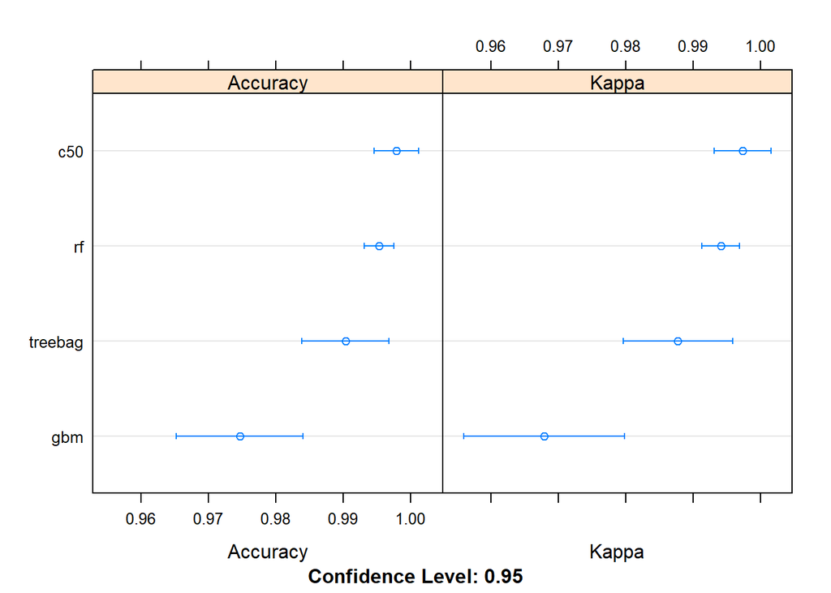

```r
dotplot(results)
```

From the above it looks like c50 had the highest accuracy.

### Model Evaluation

We are going to be evaluating the performance of the 4 models built above on our validation set by getting the class predictions.

```
##          valid_acc_rf valid_acc_gbm valid_acc_c50 valid_acc_treebag
## Accuracy    0.9962617     0.9801189     0.9991504         0.9945624
```

The c50 model had the highest accuracy on the validation test and it was quite close the accuracy on the training set which means it is likely not overfitting.

#### Variable Importance

Below is a graph showing which variables the chosen model considered significant.

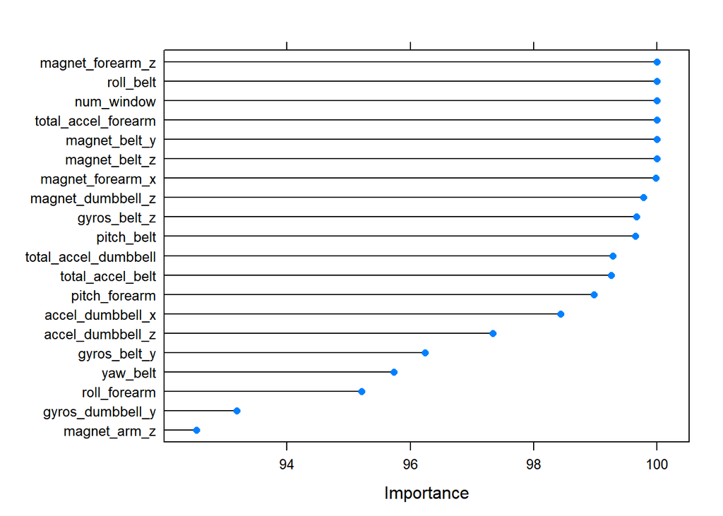

```r
c50Imp = varImp(fit.c50, scale = FALSE)
plot(c50Imp, top = 20)
```

### Model Application

#### Predict on New Data

Below we are going to apply the selected model to new data (test data). We will first have to apply the same transformations we applied to the training data.

```r
pml_testing$new_windowno <- ifelse(pml_testing$new_window=="no", 1, 0)
pml_testing$new_window = NULL
predictions = predict(fit.c50, pml_testing)
cols = c("X", "user_name", "cvtd_timestamp")
head(cbind(pml_testing[, (names(pml_testing) %in% cols)], predictions))
```

```
##   X user_name   cvtd_timestamp predictions
## 1 1     pedro 05/12/2011 14:23           B
## 2 2    jeremy 30/11/2011 17:11           A
## 3 3    jeremy 30/11/2011 17:11           B
## 4 4    adelmo 02/12/2011 13:33           A
## 5 5    eurico 28/11/2011 14:13           A
## 6 6    jeremy 30/11/2011 17:12           E
```